# Statistics 652 - Midterm

Author

Nicholas Fisher

Published

October 1, 2026

**Instructions:** Do your best to develop the models using the R tidymodels package. You can use the GitHub Copilot code completion to work on the code. Please note the there is a subdirectory in the R Project that contains R tidymodels code for all of the models you are required to build. You can use that code as a starting point for your work. I would suggest updating the code to use the new tidymodels workflow() function.

# Midterm

### Question 0

Have you used AI during the development of this midterm questions 1 and 2? If so, please describe how you used it. If not, please describe why you did not use it.

### **Answer:**

Yes. For Question 2, I used Chat GPT to help me with the code for tuning the models and running k-folds. I also had chat help me create the visualizations for the accuracy table and the validation table.

### Question 1

Clearly state the 5 steps for applying Machine Learning to a problem.

### **Answer:**

- Step 1: Determine the data to be used and where it will come from. Have a clear plan to when the data is collected and what are the variables involved in the data collection.
- Step 2: Load the data into your software within a Project Folder. Clean the data. Remove ID variables, compare the data to any test data. There may be missing factors in the training or test data. Consider altering catagorical variables, if able to trunkate them or cluster them into groups it may be more representative of the whole data. Missing data does not mean to drop the rows in numerical data consider averaging or taking the median of numerical value to replace the NA. Use AutoEDA package to check for NA’s. Consider investigating the counts of a factored variable to the outcome. Viewing counts of the outcome varible in a factor can provide initial insight into a group’s performance.
- Step 3: Develop the models you plan to investigate. To see how parameters should be tuned with large datasets, consider running an initial check on the model to see how long it takes to process the data. Then consider the number of tunes to run on the model after the initial check of the length of the model. Compare the Null model to all models created, it will be a baseline to know if the models are improving the predictions. Consider using log loss/ROC in probability predictions, Accuracy/Kappa in binary predictions.
- Step 4: Fit the models you plan to consider from Step 3. Record the accuracies, confusion matrix, any visualizations to help explain how the model is performing compared to other models.
- Step 5: Try to improved the models and determine what the final model is. After finding the predictions and best model consider rerunning the model with different tunes or boosting the model. Make the data presentable in a visualization or table as to why the model was chosen.

### Question 2

For the [titanic](https://www.kaggle.com/c/titanic/data) data set try the following machine learning classification algorithms.

Use the training and test datasets from the **titanic** R package.

You should note that the *titanic_train* has the *Survived* variable and the *titanic_test* does not. So to select your best model you need to use the *titanic_train* dataset to train and test your models. So that means you will need to select a training dataset from *titanic_train* and select a testing dataset (this would be a validation dataset) from *titanic_train* to evaluate the models you try.

I have not demonstrated the use of cross-validation, once you are comfortable running all of the models see if you can figure out how to use cross-validation to pick the best model.

Once you have picked the best model you should do the following:

1. Re-run your chosen model on the full *titanic_train* dataset.
2. Then produce predictions for the *titanic_test* dataset. This is what you would submit in a .csv to [Kaggle](https://www.kaggle.com/) in a competition.

Build **classification models** for the *Survived* variable. Pick an appropriate model scoring function, i.e. metric, and determine which model is the best. I would suggest making a confusion matrix and computing the accuracy or kappa.

0. Null Model
1. kNN (the sample code given did not scale or normalize, if you use this model you need to do that.)
2. Boosted C5.0
3. Random Forest
4. Logistic Regression using regularization
5. Naive Bayes

### **Answer**

My workflow to answer the question is in the models section. The Kappa for the whole training dataset is 0.7404776 and the Accuracy for the whole training set is 87.8%. The code I used at the end for my best model is here. I share my results for all the models accuracy and Kappa in the *Accuracy Table* and *Kappa Table*.

### Question 3

Use AI to help you with the code development for implementing Cross-Validation. You can use [ChatGPT](https://chatgpt.com/), [Copliot](https://m365.cloud.microsoft/chat), [Codex](https://chatgpt.com/codex), [Antigravity](https://antigravity.google/), etc.

Make one plot containing all of the ROC curves for the algorithms trained.

### **Answer:**

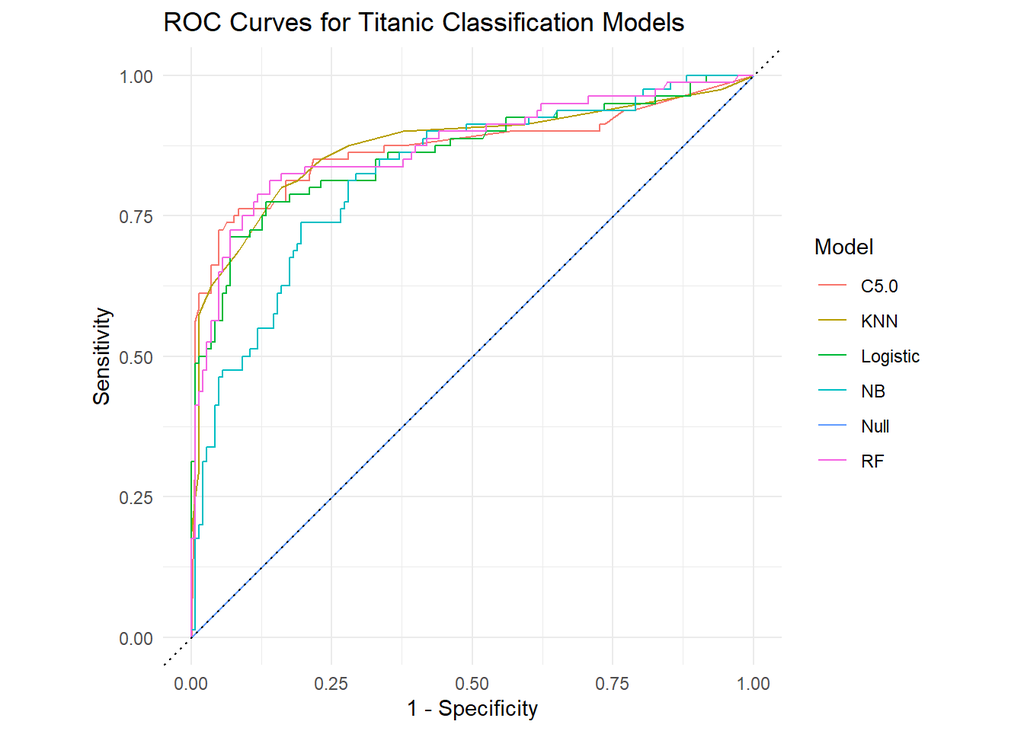

| Model | AUC |
| --- | --- |
| RF | 0.874 |
| KNN | 0.874 |
| C5.0 | 0.870 |
| Logistic | 0.861 |
| NB | 0.823 |
| Null | 0.500 |

The code for the ROC model is at the bottom of my midterm. Although AUC claims Random Forests and KNN have better classifications than Boosted C5.0. My Kappa and Accuracy have claimed Boosted C5.0 has the better model. For model selection for the Kaggle Competition I will be choosing Boosted C5.0 with 11 trees for my model specification. ROC Code

# Load Data and Packages

```r
library(pacman)
p_load(readr, tidyverse, naivebayes, glmnet, randomForest, tidymodels, leaps,
       kknn, yardstick, parsnip, mdsr, olsrr, skimr, C50, ranger,
       rpart, partykit, pROC, modelr, rsample, car, discrim, klaR)


titanic_train <- read.csv("train.csv")
titanic_test <- read.csv("test.csv")

data(titanic_train)
data(titanic_test)

head(titanic_train)
head(titanic_test)
```

# Data Cleaning

## Data Cleaning Code

```r
#change Cabin to Letter in Testing Data.
titanic_train <- titanic_train |>
  dplyr::mutate(Cabin = substr(Cabin, 1, 1))

#Factor training data
titanic_train <- titanic_train |>
  dplyr::mutate(across(c(Sex, Pclass, Survived, Cabin, SibSp, Embarked), as.factor))

#Set NA Age to Median Value
titanic_train <- titanic_train |>
  dplyr::mutate(
    Age = replace_na(
      Age,
      median(Age, na.rm = TRUE)
    )
  )

#Drop observation for Cabin "T"
titanic_train <- titanic_train[-340, ]

#Change Cabin to Letter in Testing data.
titanic_test <- titanic_test |>
  dplyr::mutate(Cabin = substr(Cabin, 1, 1))

#Factor features for Test data
titanic_test <- titanic_test |>
  dplyr::mutate(across(c(Sex, Pclass, Cabin, SibSp, Embarked), as.factor))

#Convert Age to median in Test data
titanic_test <- titanic_test |>
  dplyr::mutate(
    Age = replace_na(
      Age,
      median(Age, na.rm = TRUE)
    )
  )

#Change NA Fare to median in test data.
titanic_test <- titanic_test |>
  dplyr::mutate(
    Fare = replace_na(
      Fare,
      median(Fare, na.rm = TRUE)
    )
  )

#Change missing rows to "Unknown" in training data
titanic_test <- titanic_test |>
  dplyr::mutate(
    Cabin = as.character(Cabin),
    Embarked = as.character(Embarked),

    Cabin = ifelse(Cabin == "", "Unknown", Cabin),
    Embarked = ifelse(Embarked == "", "Unknown", Embarked),

    Cabin = factor(Cabin),
    Embarked = factor(Embarked)
  )

#Change missing rows to "Unknown" in test data
titanic_train <- titanic_train |>
  dplyr::mutate(
    Cabin = as.character(Cabin),
    Embarked = as.character(Embarked),

    Cabin = ifelse(Cabin == "", "Unknown", Cabin),
    Embarked = ifelse(Embarked == "", "Unknown", Embarked),

    Cabin = factor(Cabin),
    Embarked = factor(Embarked)
  )

sum(is.na(titanic_test$Fare))
#drop name, ticket, cabin,


# create_report(titanic_train)
# create_report(titanic_test)

#Check for different levels in factor variables.
factor_cols <- names(titanic_train)[sapply(titanic_train, is.factor)]

for (col in factor_cols) {
  new_levels <- setdiff(
    unique(titanic_test[[col]]),
    unique(titanic_train[[col]])
  )

  if (length(new_levels) > 0) {
    cat(col, ":", new_levels, "\n")
  }
}

titanic_train <- titanic_train |>
  dplyr::select(-c(Ticket, Name, PassengerId))

titanic_test <- titanic_test |>
  dplyr::select(-c(Ticket, Name))

set.seed(134928)
titanic_parts <- titanic_train |>
  initial_split(prop = .75)
titan_train <- titanic_parts |>
  training()
titan_valid <- titanic_parts |>
  testing()
```

# Model 0 Null Model

### **Answer:**

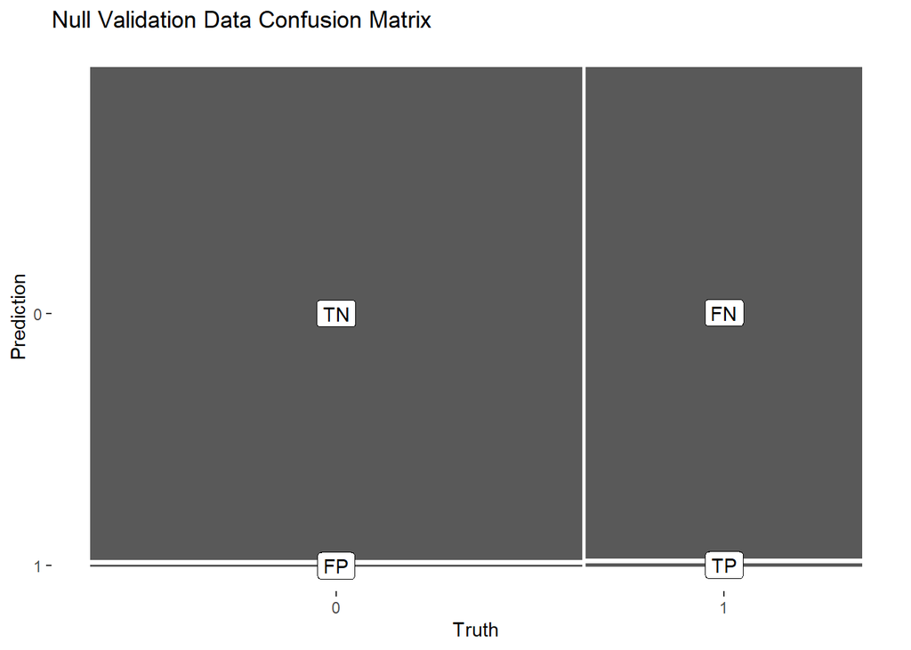

| .metric | .estimator | .estimate |
| --- | --- | --- |
| accuracy | binary | 0.6412556 |

### **Code and Comments:**

```r
# creating the model
mod_null <- logistic_reg(mode = "classification") %>%
  set_engine("glm") %>%
  fit(Survived ~ 1, data = titan_train)

saveRDS(mod_null, "mod_null.rds")

#Creating the predicted class on the training data
titan_pred_train <- titan_train |>
  dplyr::select(Survived) |>
  bind_cols(predict(mod_null, new_data = titan_train, type = "class")) |>
  rename(survived_null = .pred_class)

#Confusion Matrix on training data
confusion_null_train <- titan_pred_train |>
  conf_mat(truth = Survived, estimate = survived_null)

autoplot(confusion_null_train) +
  labs(title = "Null Training Data Confusion Matrix")+
    geom_label(aes(
      x = (xmax + xmin) / 2,
      y = (ymax + ymin) / 2,
      label = c("TN", "FP", "FN", "TP")))

# Accuracy Results on the training
accuracy(titan_pred_train, Survived, survived_null)

# Validation data Prediction Class
titan_pred_valid <- titan_valid |>
  dplyr::select(Survived) |>
  bind_cols(predict(mod_null, new_data = titan_valid, type = "class")) |>
  rename(survived_null = .pred_class)

# Confusion Matrix on Null model Validation Data
confusion_null_valid <- titan_pred_valid |>
  conf_mat(truth = Survived, estimate = survived_null)


null_valid_conf_plot <- autoplot(confusion_null_valid) +
  labs(title = "Null Validation Data Confusion Matrix")+
    geom_label(aes(
      x = (xmax + xmin) / 2,
      y = (ymax + ymin) / 2,
      label = c("TN", "FP", "FN", "TP")))

saveRDS(confusion_null_valid, "confusion_null_valid")
saveRDS(null_valid_conf_plot, "null_valid_conf_plot")

# Accuracy of the Validation Data with the null model
accuracy_null_valid <- accuracy(titan_pred_valid, Survived, survived_null)
saveRDS(accuracy_null_valid, "accuracy_null_valid")
```

# Model 1 kNN

### **Answer:**

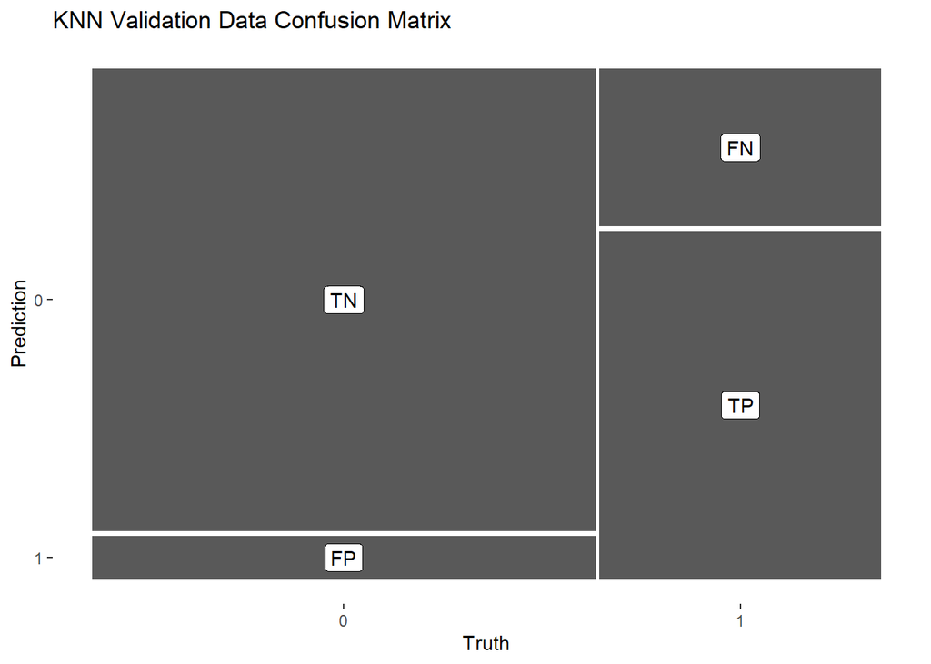

| .metric | .estimator | .estimate |
| --- | --- | --- |
| accuracy | binary | 0.8340807 |

### **Code and Comments:**

```r
knn_spec <- nearest_neighbor(
  neighbors = tune(),
  weight_func = "rectangular",
  dist_power = 2
) |>
  set_engine("kknn") |>
  set_mode("classification")

set.seed(2435)

knn_folds <- vfold_cv(
  titan_train,
  v = 5,
  strata = Survived
)

knn_recipe <- recipe(Survived ~ ., data = titan_train) |>
  step_impute_median(all_numeric_predictors()) |>
  step_unknown(all_nominal_predictors()) |>
  step_dummy(all_nominal_predictors()) |>
  step_normalize(all_numeric_predictors())

knn_wf <- workflow() |>
  add_recipe(knn_recipe) |>
  add_model(knn_spec)
knn_grid <- tibble(
  neighbors = 1:30
)

set.seed(123)

knn_tune <- tune_grid(
  knn_wf,
  resamples = knn_folds,
  grid = knn_grid,
  metrics = metric_set(accuracy)
)
collect_metrics(knn_tune)

best_knn <- select_best(
  knn_tune,
  metric = "accuracy"
)

best_knn




#training KNN model with K = 17
knn_mod <-
  nearest_neighbor(weight_func = "rectangular", neighbors = 17) |>
  set_mode("classification") |>
  set_engine("kknn") |>
  fit(Survived ~ ., data = titan_train)

saveRDS(knn_mod, "knn_mod")

#Prediction class of KNN with Training data
titan_pred_train <- titan_pred_train |>
  dplyr::select(Survived, survived_null) |>
  bind_cols(predict(knn_mod, new_data = titan_train, type = "class")) |>
  rename(survived_knn = .pred_class)

#Confusion matrix of training Data with KNN
confusion_null_train <- titan_pred_train |>
  conf_mat(truth = Survived, estimate = survived_knn)

autoplot(confusion_null_train) +
  labs(title = "KNN Training Data Confusion Matrix")+
    geom_label(aes(
      x = (xmax + xmin) / 2,
      y = (ymax + ymin) / 2,
      label = c("TN", "FP", "FN", "TP")))

#accuracy of training data for KNN
accuracy(titan_pred_train, Survived, survived_knn)

# running KNN model with validation data
titan_pred_valid <- titan_pred_valid |>
  dplyr::select(Survived, survived_null) |>
  bind_cols(predict(knn_mod, new_data = titan_valid, type = "class")) |>
  rename(survived_knn = .pred_class)

# Confusion matrix for KNN with validation data
confusion_knn_valid <- titan_pred_valid |>
  conf_mat(truth = Survived, estimate = survived_knn)

knn_valid_conf_plot <- autoplot(confusion_knn_valid) +
  labs(title = "KNN Validation Data Confusion Matrix")+
    geom_label(aes(
      x = (xmax + xmin) / 2,
      y = (ymax + ymin) / 2,
      label = c("TN", "FP", "FN", "TP")))

saveRDS(confusion_knn_valid, "confusion_knn_valid")
saveRDS(knn_valid_conf_plot, "knn_valid_conf_plot")

# Accuracy for KNN model for Validation Data
accuracy_knn_valid <- accuracy(titan_pred_valid, Survived, survived_knn)

saveRDS(accuracy_knn_valid, "accuracy_knn_valid")
```

# Model 2 Boosted C5.0

### **Answer:**

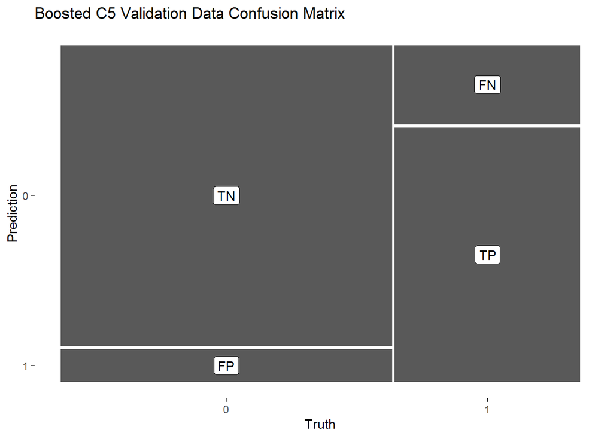

[output not shown]

### **Code and Comments:**

```r
#C5 tuning
set.seed(2483)

c5_folds <- vfold_cv(
  titan_train,
  v = 5,
  strata = Survived)

c5_spec <- boost_tree(
  trees = tune()) |>
  set_engine("C5.0") |>
  set_mode("classification")

c5_workflow <- workflow() |>
  add_formula(Survived ~ .) |>
  add_model(c5_spec)

c5_grid <- tibble(
  trees = c(8, 9, 10, 11, 12, 13, 14)
)

set.seed(123)

c5_tune <- c5_workflow |>
  tune_grid(
    resamples = c5_folds,
    grid = c5_grid,
    metrics = metric_set(accuracy)
  )

c5_tune |>
  collect_metrics()

#Create Boosted C5.0 Model with Training Data
c5_mod <- boost_tree(trees = 11) |>
  set_engine("C5.0") |>
  set_mode("classification") |>
  fit(Survived ~ ., data = titan_train)

# Create Prediction Class with Training Data
titan_pred_train <- titan_pred_train |>
  dplyr::select(Survived, survived_null, survived_knn) |>
  bind_cols(predict(c5_mod, new_data = titan_train, type = "class")) |>
  rename(survived_c5 = .pred_class)

# Create Confusion Matrix with Boosted C5 predictions
confusion_c5_train <- titan_pred_train |>
  conf_mat(truth = Survived, estimate = survived_c5)

autoplot(confusion_c5_train) +
  labs(title = "Boosted C5 Data Confusion Matrix")+
    geom_label(aes(
      x = (xmax + xmin) / 2,
      y = (ymax + ymin) / 2,
      label = c("TN", "FP", "FN", "TP")))


#Find accuracy of Boosted C5 model training data predictions
accuracy(titan_pred_train, Survived, survived_c5)


#Apply Boosted C5.0 model for Validation Data
titan_pred_valid <- titan_pred_valid |>
  dplyr::select(Survived, survived_null, survived_knn) |>
  bind_cols(predict(c5_mod, new_data = titan_valid, type = "class")) |>
  rename(survived_c5 = .pred_class)

#Generate Confusion matrix
confusion_c5_valid <- titan_pred_valid |>
  conf_mat(truth = Survived, estimate = survived_c5)

c5_valid_conf_plot <- autoplot(confusion_c5_valid) +
  labs(title = "Boosted C5 Validation Data Confusion Matrix")+
    geom_label(aes(
      x = (xmax + xmin) / 2,
      y = (ymax + ymin) / 2,
      label = c("TN", "FP", "FN", "TP")))

saveRDS(confusion_c5_valid, "confusion_c5_valid")
saveRDS(c5_valid_conf_plot, "c5_valid_conf_plot")

#Find Accuracy of Confusion Matrix
accuracy_c5_valid <- accuracy(titan_pred_valid, Survived, survived_c5)

saveRDS(accuracy_c5_valid ,"accuracy_c5_valid")
```

# Model 3 Random Forest

### **Answer:**

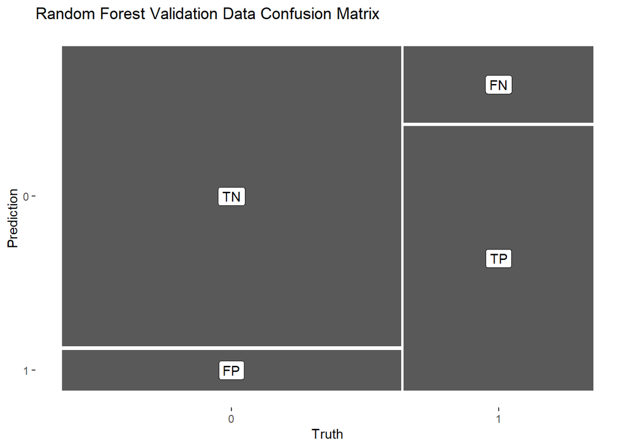

| .metric | .estimator | .estimate |
| --- | --- | --- |
| accuracy | binary | 0.8430493 |

I ran tuning on random forest and got mtry = 4 and min_n = 5 to be our best tuning parameter. I will set the model and I got an accuracy of 84.3%.

### **Code and Comments:**

```r
#Tuned Random Forest
set.seed(2483)

# 5-fold cross-validation
rf_folds <- vfold_cv(
  titan_train,
  v = 5,
  strata = Survived
)

# Random Forest specification
rf_spec <- rand_forest(
  trees = 500,
  mtry = tune(),
  min_n = tune()
) |>
  set_engine("ranger") |>
  set_mode("classification")

# Workflow
rf_workflow <- workflow() |>
  add_formula(Survived ~ .) |>
  add_model(rf_spec)

# Tuning grid
rf_grid <- expand_grid(
  mtry = 1:8,
  min_n = c(2, 5, 10, 15, 20)
)

set.seed(123)

# Tune model
rf_tune <- rf_workflow |>
  tune_grid(
    resamples = rf_folds,
    grid = rf_grid,
    metrics = metric_set(accuracy)
  )

# See tuning results
rf_tune |>
  collect_metrics()

best_rf <- rf_tune |>
  select_best(metric = "accuracy")

best_rf

#Use the best parameters for the RF model from the training data
rf_mod <- rf_workflow |>
  finalize_workflow(best_rf) |>
  fit(data = titan_train)

#predict training data with RF model
titan_pred_train <- titan_pred_train |>
  dplyr::select(Survived, survived_null, survived_knn, survived_c5) |>
  bind_cols(predict(rf_mod, new_data = titan_train, type = "class")) |>
  rename(survived_rf = .pred_class)

#Generate Confusion Matrix
confusion_rf_train <- titan_pred_train |>
  conf_mat(truth = Survived, estimate = survived_rf)

autoplot(confusion_rf_train) +
  labs(title = "Random Forest Training Data Confusion Matrix")+
    geom_label(aes(
      x = (xmax + xmin) / 2,
      y = (ymax + ymin) / 2,
      label = c("TN", "FP", "FN", "TP")))

#Find accuracy
accuracy(titan_pred_train, Survived, survived_rf)

#Run RF model on validation Data
titan_pred_valid <- titan_pred_valid |>
  dplyr::select(Survived, survived_null, survived_knn, survived_c5) |>
  bind_cols(predict(rf_mod, new_data = titan_valid, type = "class")) |>
  rename(survived_rf = .pred_class)

# Run confusion matrix
confusion_rf_valid <- titan_pred_valid |>
  conf_mat(truth = Survived, estimate = survived_rf)

rf_valid_conf_plot <- autoplot(confusion_rf_valid) +
  labs(title = "Random Forest Validation Data Confusion Matrix")+
    geom_label(aes(
      x = (xmax + xmin) / 2,
      y = (ymax + ymin) / 2,
      label = c("TN", "FP", "FN", "TP")))

saveRDS(confusion_rf_valid, "confusion_rf_valid")
saveRDS(rf_valid_conf_plot, "rf_valid_conf_plot")

#Find Accuracy
accuracy_rf_valid <- accuracy(titan_pred_valid, Survived, survived_rf)

saveRDS(accuracy_rf_valid ,"accuracy_rf_valid")
```

# Model 4 Logistic Regression using regularization

### **Answer:**

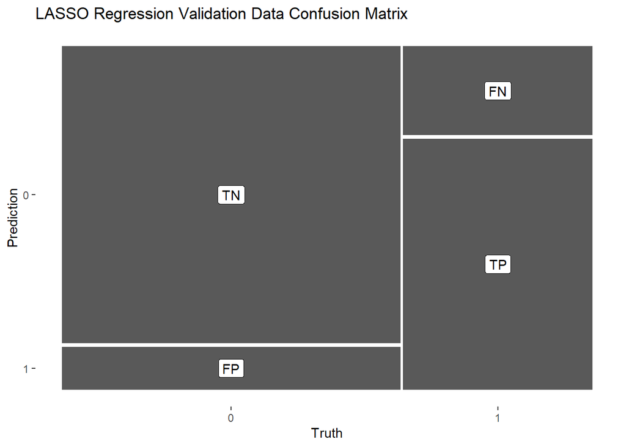

| .metric | .estimator | .estimate |
| --- | --- | --- |
| accuracy | binary | 0.8251121 |

Our accuracy for the model is 82.5% for LASSO regression model. From tuning LASSO our penality cost is 0.002395027.

### **Code and Comments:**

```r
#Tuning for LASSO regularization
set.seed(2483)

lasso_folds <- vfold_cv(
  titan_train,
  v = 5,
  strata = Survived
)

# Recipe
lasso_recipe <- recipe(Survived ~ ., data = titan_train) |>
  step_dummy(all_nominal_predictors())

# LASSO logistic regression
lasso_spec <- logistic_reg(
  penalty = tune(),
  mixture = 1
) |>
  set_engine("glmnet") |>
  set_mode("classification")

# Workflow
lasso_workflow <- workflow() |>
  add_recipe(lasso_recipe) |>
  add_model(lasso_spec)

lasso_grid <- grid_regular(
  penalty(range = c(-4, 0)),
  levels = 30
)

set.seed(123)

lasso_tune <- lasso_workflow |>
  tune_grid(
    resamples = lasso_folds,
    grid = lasso_grid,
    metrics = metric_set(accuracy)
  )

lasso_tune |>

  collect_metrics()
best_lasso <- lasso_tune |>
  select_best(metric = "accuracy")

best_lasso

#Create Lasso Model from training set with best parameters
lasso_mod <- lasso_workflow |>
  finalize_workflow(best_lasso) |>
  fit(data = titan_train)

#Run predictions of LASSO Model on training data
titan_pred_train <- titan_pred_train |>
  dplyr::select(Survived, survived_null, survived_knn,
               survived_c5, survived_rf) |>
  bind_cols(predict(lasso_mod, new_data = titan_train,
      type = "class") |>
      rename(survived_lasso = .pred_class))

#Generate Confusion Matrix
confusion_lasso_train <- titan_pred_train |>
  conf_mat(truth = Survived, estimate = survived_lasso)

autoplot(confusion_lasso_train) +
  labs(title = "LASSO Regression Training Data Confusion Matrix")+
    geom_label(aes(
      x = (xmax + xmin) / 2,
      y = (ymax + ymin) / 2,
      label = c("TN", "FP", "FN", "TP")))

#Find accuracy of training model for LASSO
accuracy(titan_pred_train, Survived, survived_lasso)


#Run LASSO model on validation Data predictions
titan_pred_valid <- titan_pred_valid |>
  dplyr::select(Survived, survived_null, survived_knn,
               survived_c5, survived_rf) |>
  bind_cols(predict(lasso_mod, new_data = titan_valid,
      type = "class") |>
      rename(survived_lasso = .pred_class))

#Create confusion Matrix
confusion_lasso_valid <- titan_pred_valid |>
  conf_mat(truth = Survived, estimate = survived_lasso)

lasso_valid_conf_plot <- autoplot(confusion_lasso_valid) +
  labs(title = "LASSO Regression Validation Data Confusion Matrix")+
    geom_label(aes(
      x = (xmax + xmin) / 2,
      y = (ymax + ymin) / 2,
      label = c("TN", "FP", "FN", "TP")))

saveRDS(confusion_lasso_valid ,"confusion_lasso_valid")
saveRDS(lasso_valid_conf_plot,"lasso_valid_conf_plot")

#Find accuracy of LASSO model on Validation Data
accuracy_lasso_valid <- accuracy(titan_pred_valid, Survived, survived_lasso)

saveRDS(accuracy_lasso_valid, "accuracy_lasso_valid")
```

# Model 5 Naive Bayes

### **Answer:**

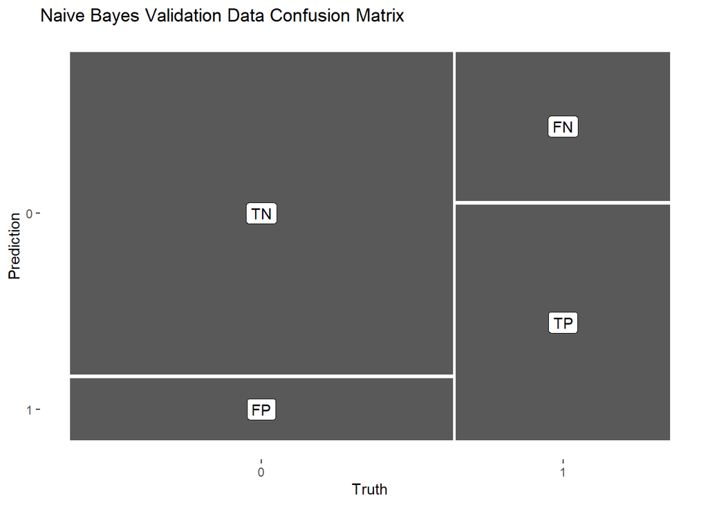

| .metric | .estimator | .estimate |
| --- | --- | --- |
| accuracy | binary | 0.7578475 |

Our accuracy on the Validation Data is 75.8%. With a tune of smoothness = 0.5 and Laplace = 2.

### **Code and Comments:**

```r
#Tune Naive Bayes
nb_folds <- vfold_cv(
  titan_train,
  v = 5,
  strata = Survived
)

# Naive Bayes specification
nb_spec <- naive_Bayes(
  smoothness = tune(),
  Laplace = tune()
) |>
  set_engine("naivebayes") |>
  set_mode("classification")

# Workflow
nb_workflow <- workflow() |>
  add_formula(Survived ~ .) |>
  add_model(nb_spec)

nb_grid <- expand_grid(
  smoothness = c(0.5, 1, 1.5, 2),
  Laplace = c(0, 1, 2)
)

set.seed(123)

nb_tune <- nb_workflow |>
  tune_grid(
    resamples = nb_folds,
    grid = nb_grid,
    metrics = metric_set(accuracy)
  )

nb_tune |>
  collect_metrics()

best_nb <- nb_tune |>
  select_best(metric = "accuracy")

#Create Naive Bayes Model with training data
nb_mod <- nb_workflow |>
  finalize_workflow(best_nb) |>
  fit(data = titan_train)

#Run predictions of training data with Naive Bayes model
titan_pred_train <- titan_pred_train |>
  dplyr::select(Survived, survived_null, survived_knn,
               survived_c5, survived_rf, survived_lasso) |>
  bind_cols(predict(nb_mod, new_data = titan_train,
                    type = "class") |>
      rename(survived_nb = .pred_class))

#Create Confusion Matrix
confusion_nb_train <- titan_pred_train |>
  conf_mat(truth = Survived, estimate = survived_nb)

autoplot(confusion_nb_train) +
  labs(title = "Naive Bayes Training Data Confusion Matrix")+
    geom_label(aes(
      x = (xmax + xmin) / 2,
      y = (ymax + ymin) / 2,
      label = c("TN", "FP", "FN", "TP")))

#Find Accuracy
accuracy(titan_pred_train, Survived, survived_nb)

#Run Naive Bayes Model on Validation Data
titan_pred_valid <- titan_pred_valid |>
  dplyr::select(Survived, survived_null, survived_knn,
               survived_c5, survived_rf, survived_lasso) |>
  bind_cols(predict(nb_mod, new_data = titan_valid,
                    type = "class") |>
      rename(survived_nb = .pred_class))

#Create Confusion Matrix for Validation Data for Naive Bayes
confusion_nb_valid <- titan_pred_valid |>
  conf_mat(truth = Survived, estimate = survived_nb)

nb_valid_conf_plot <- autoplot(confusion_nb_valid) +
  labs(title = "Naive Bayes Validation Data Confusion Matrix")+
    geom_label(aes(
      x = (xmax + xmin) / 2,
      y = (ymax + ymin) / 2,
      label = c("TN", "FP", "FN", "TP")))

saveRDS(confusion_nb_valid ,"confusion_nb_valid")
saveRDS(nb_valid_conf_plot,"nb_valid_conf_plot")

#Find accuracy of Naive Bayes Model
accuracy_nb_valid <- accuracy(titan_pred_valid, Survived, survived_nb)

saveRDS(accuracy_nb_valid, "accuracy_nb_valid")
```

# Accuracy Table

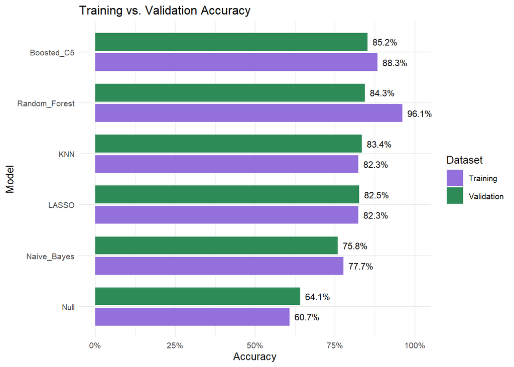

We see from our bar graph our Boosted C5.0 has the best accuracy for the validation data. We can see our Naive Bayes, Random Forests and Boosted C5.0 had some overfitting from the training data as well. Only focusing on the validation metrics for our validation data, Boosted C5.0 performed the best.

## Code and Comments

```r
#Sum of all accuracies from the training data
accuracy_table_train <- titan_pred_train |>
  summarise(
    Null = accuracy_vec(Survived, survived_null),
    KNN = accuracy_vec(Survived, survived_knn),
    Random_Forest = accuracy_vec(Survived, survived_rf),
    Boosted_C5 = accuracy_vec(Survived, survived_c5),
    LASSO = accuracy_vec(Survived, survived_lasso),
    Naive_Bayes = accuracy_vec(Survived, survived_nb)
  ) |>
  pivot_longer(
    everything(),
    names_to = "Model",
    values_to = "Accuracy"
  ) |>
  arrange(desc(Accuracy))

saveRDS(accuracy_table_train, "accuracy_table_train")


#Create table for accuracy of Validation Data
accuracy_valid <- titan_pred_valid |>
  summarise(
    Null = accuracy_vec(Survived, survived_null),
    KNN = accuracy_vec(Survived, survived_knn),
    Random_Forest = accuracy_vec(Survived, survived_rf),
    Boosted_C5 = accuracy_vec(Survived, survived_c5),
    LASSO = accuracy_vec(Survived, survived_lasso),
    Naive_Bayes = accuracy_vec(Survived, survived_nb)
  ) |>
  pivot_longer(
    everything(),
    names_to = "Model",
    values_to = "Accuracy"
  ) |>
  arrange(desc(Accuracy))

saveRDS(accuracy_valid, "accuracy_valid")

#making plot
# Make C5 naming consistent

# Add dataset labels
accuracy_table_train <- accuracy_table_train |>
  mutate(Data = "Training")

accuracy_valid <- accuracy_valid |>
  mutate(Data = "Validation")

# Combine
accuracy_compare <- bind_rows(
  accuracy_table_train,
  accuracy_valid
)
library(ggplot2)
# Horizontal side-by-side bar plot
accuracy_comp <- ggplot(
  accuracy_compare,
  aes(
    x = reorder(
      Model,
      Accuracy * (Data == "Validation"),
      FUN = max
    ),
    y = Accuracy,
    fill = Data
  )
) +
  geom_col(
    position = position_dodge(width = 0.8),
    width = 0.7
  ) +
  geom_text(
    aes(label = scales::percent(Accuracy, accuracy = 0.1)),
    position = position_dodge(width = 0.8),
    hjust = -0.2,
    size = 3
  ) +
  scale_fill_manual(
    values = c(
      "Training" = "mediumpurple",
      "Validation" = "seagreen"
    )
  ) +
  scale_y_continuous(
    labels = scales::percent_format(),
    limits = c(0, 1)
  ) +
  coord_flip() +
  labs(
    title = "Training vs. Validation Accuracy",
    x = "Model",
    y = "Accuracy",
    fill = "Dataset"
  ) +
  theme_minimal(base_size = 10)

saveRDS(accuracy_comp, "accuracy_comp")
```

# Kappa Table

[figure not shown]

As we see from the bar graph our bars have the validation data descending by Kappa scores. Our model with the best Kappa is again Boosted C5.0. We will use this model to run the Kaggle Predictions.

## Code and Comments

```r
#Investigate Kappa on training data
kappa_table <- titan_pred_train |>
  summarise(
    Null = kap_vec(Survived, survived_null),
    KNN = kap_vec(Survived, survived_knn),
    Random_Forest = kap_vec(Survived, survived_rf),
    Boosted_C5 = kap_vec(Survived, survived_c5),
    LASSO = kap_vec(Survived, survived_lasso),
    Naive_Bayes = kap_vec(Survived, survived_nb)
  ) |>
  pivot_longer(
    everything(),
    names_to = "Model",
    values_to = "Kappa"
  )

kappa_train <- kappa_table |>
  arrange(desc(Kappa)) |>
  mutate(round(Kappa, 3))

saveRDS(kappa_train, "kappa_train")

#Investigate Kappa on Validation data predictions
kappa_valid <- titan_pred_valid |>
  summarise(
    Null = kap_vec(Survived, survived_null),
    KNN = kap_vec(Survived, survived_knn),
    Random_Forest = kap_vec(Survived, survived_rf),
    Boosted_C5 = kap_vec(Survived, survived_c5),
    LASSO = kap_vec(Survived, survived_lasso),
    Naive_Bayes = kap_vec(Survived, survived_nb)
  ) |>
  pivot_longer(
    everything(),
    names_to = "Model",
    values_to = "Kappa"
  )

kappa_valid <- kappa_valid |>
  arrange(desc(Kappa))

saveRDS(kappa_valid, "kappa_valid")

# Add dataset labels
kappa_train <- kappa_train |>
  mutate(Data = "Training")

kappa_valid <- kappa_valid |>
  mutate(Data = "Validation")

# Combine training and validation Kappa
kappa_compare <- bind_rows(
  kappa_train,
  kappa_valid
)

# Create horizontal side-by-side bar plot
Kappa_comp <-ggplot(
  kappa_compare,
  aes(
    x = reorder(
      Model,
      Kappa * (Data == "Validation"),
      FUN = max
    ),
    y = Kappa,
    fill = Data
  )
) +
  geom_col(
    position = position_dodge(width = 0.8),
    width = 0.7
  ) +
  geom_text(
    aes(label = round(Kappa, 3)),
    position = position_dodge(width = 0.8),
    hjust = -0.2,
    size = 3
  ) +
  scale_fill_manual(
    values = c(
      "Training" = "mediumpurple",
      "Validation" = "seagreen"
    )
  ) +
  coord_flip() +
  labs(
    title = "Training vs. Validation Kappa",
    x = "Model",
    y = "Kappa",
    fill = "Dataset"
  ) +
  theme_minimal(base_size = 10)

saveRDS(Kappa_comp, "Kappa_comp")
```

# ROC Code Question 3

Have to convert to predicted class to probabilities. From Chat GPT.

```r
#Create ROC probabilities
titan_roc <- tibble(
  Survived = titan_valid$Survived,

  Null = predict(null_mod, titan_valid, type = "prob")$.pred_1,

  KNN = predict(knn_mod, titan_valid, type = "prob")$.pred_1,

  C5.0 = predict(c5_mod, titan_valid, type = "prob")$.pred_1,

  RF = predict(rf_mod, titan_valid, type = "prob")$.pred_1,

  Logistic = predict(lasso_mod, titan_valid, type = "prob")$.pred_1,

  NB = predict(nb_mod, titan_valid, type = "prob")$.pred_1
)
# Actual outcome
actual <- titan_roc$Survived

# Predicted probabilities from each model
# Replace these object names with your actual prediction objects

roc_null <- roc(actual, titan_roc$Null)
roc_lasso <- roc(actual, titan_roc$Logistic)
roc_knn   <- roc(actual,titan_roc$KNN)
roc_nb    <- roc(actual, titan_roc$NB)
roc_rf    <- roc(actual, titan_roc$RF)
roc_c5   <- roc(actual, titan_roc$C5.0)

titan_roc_long <- titan_roc |>
  pivot_longer(
    cols = -Survived,
    names_to = "Model",
    values_to = ".pred_1"
  )

# Calculate ROC curves for every model
roc_results <- titan_roc_long |>
  group_by(Model) |>
  roc_curve(
    truth = Survived,
    .pred_1,
    event_level = "second"
  )

# Plot all ROC curves
ROC_model <- autoplot(roc_results) +
  labs(
    title = "ROC Curves for Titanic Classification Models",
    x = "1 - Specificity",
    y = "Sensitivity"
  ) +
  theme_minimal()

saveRDS(ROC_model, "ROC_model")

#Create table of AUC's for all models
AUC_model <- titan_roc_long |>
  group_by(Model) |>
  roc_auc(
    truth = Survived,
    .pred_1,
    event_level = "second"
  ) |>
  arrange(desc(.estimate))

AUC_model <- AUC_model |>
  mutate(AUC = round(.estimate, 3))|>
  dplyr::select(Model, AUC)|>
  knitr::kable()

saveRDS(AUC_model, "AUC_model")
```

# Best Model

The best output is **Boosted C5.0** with the parameter of 11 trees. Our Kappa and Accuracy for this model for the whole training data is 0.7404776 for our Kappa and an accuracy of 87.8%.

## Code

```r
c5_mod_final <- boost_tree(trees = 11) |>
  set_engine("C5.0") |>
  set_mode("classification") |>
  fit(Survived ~ ., data = titanic_train)

titanic_train_prediction <- titanic_train |>
  dplyr::select(Survived) |>
  bind_cols(predict(c5_mod_final, new_data = titanic_train,
                    type = "class") |>
      rename(pred_full = .pred_class))

accuracy(titanic_train_prediction, Survived, pred_full)
summarise(KAPPA = kap_vec(Survived, pred_full), titanic_train_prediction)
```

[output not shown]

# Submission File

Code for uploading my predicted outcomes on Kaggle.

```r
titanic_test_prediction <- titanic_test |>
  dplyr::select(PassengerId) |>
  bind_cols(predict(c5_mod_final, new_data = titanic_test,
                    type = "class") |>
      rename(Survived = .pred_class))
submission <- titanic_test_prediction

saveRDS(submission, "submission")
write.csv(submission, "submission.csv", row.names = F)
```